# Predicting Netflix’s Next Hit:

# 1. Data-Driven Insights for Optimizing Netflix’s Content Strategy

ZACHARY FLETCHER, LAURYN MURPHY, JORDAN POLAREK

**Organization & Business Problem:**

Netflix, Inc. (Global leader in entertainment streaming)

Business problem: Netflix faces rising competition in the streaming market and high content production costs.

**Our objective:** Use data analytics to predict which types of content drive engagement and subscriber growth — identify which genres, formats, and audience segments yield the highest engagement.

# 2. Business Problem & Context

**Why this problem matters (business impact):** The business impact includes better allocation of billions in content spending and minimizing losses on low-performing shows and movies

**Relevant industry or market factors:** The global streaming market is expanding rapidly, led by major players such as Netflix, Disney+, Prime Video, Hulu, and Apple TV+. Streaming now accounts for 45.2% of U.S. TV usage (Statista), with users averaging 60+ hours per month. Globally, it makes up over 80% of music and video entertainment revenue (Pangarkar) and is projected to reach $223.98 billion by 2028, growing at ~21% CAGR (Market.us, 2025).

Key trends include rising demand for genre diversity, localized content, and binge-worthy series, driving intense competition for subscribers.

# 3. Data Sources & References

**Links to datasets used (original sources, not just download locations)**

https://www.kaggle.com/datasets/bhargavchirumamilla/netflix-movies-and-tv-shows-till-2025?resource=download

**Brief explanation of each dataset’s contents**

The dataset also provides numbers that help measure audience interest, such as popularity scores, user ratings, and vote counts. Some titles also include budget and revenue information. Overall, the dataset gives a broad view of Netflix’s content library, making it useful for understanding trends, popularity patterns, and performance of different types of content.

**Citation of at least two credible references for the business context**

1. Forbes: Video Streaming Industry Growth & Competition

A business analysis that talks about global streaming growth, competition, and user behavior—perfect for explaining why Netflix needs data driven content decisions.

Citation: Pangarkar, A. (2024). The growing dominance of video streaming services. Forbes. https://www.forbes.com/sites/anilpangarkar/2024/03/18/the-growing-dominance-of-video-streaming/

2. Statista: Market & Viewer Behavior Data

Independent market data on U.S. streaming usage; supports points about rising competition and the importance of content engagement.

Citation: Statista. (2025). Share of TV viewing time in the United States, by platform. https://www.statista.com/statistics/1337515/tv-viewing-share-platform-us/

# 4. Data Acquisition & Loading

```python
import pandas as pd

# --- Change this URL to your CSV file's URL ---
csv_url = 'https://raw.githubusercontent.com/Zacfletch6/IS_submissions/refs/heads/main/Business%20Analytics%20Project/netflix_movies_detailed_up_to_2025.csv'

# --- Load into pandas DataFrame ---
df = pd.read_csv(csv_url)

# --- Fix date_added and extract year ---
df['date_added'] = pd.to_datetime(df['date_added'], errors='coerce')
df['year_added'] = df['date_added'].dt.year

# --- Quick check ---
df.head()
```

|  | show_id | type | title | director | cast | country | date_added | release_year | rating | duration | genres | language | description | popularity | vote_count | vote_average | budget | revenue | year_added |
| --- | --- | --- | --- | --- | --- | --- | --- | --- | --- | --- | --- | --- | --- | --- | --- | --- | --- | --- | --- |
| 0 | 10192 | Movie | Shrek Forever After | Mike Mitchell | Mike Myers, Eddie Murphy, Cameron Diaz, Antoni... | United States of America | 2010-05-16 | 2010 | 6.380 | NaN | Comedy, Adventure, Fantasy, Animation, Family | en | A bored and domesticated Shrek pacts with deal... | 203.893 | 7449 | 6.380 | 165000000 | 752600867 | 2010 |
| 1 | 27205 | Movie | Inception | Christopher Nolan | Leonardo DiCaprio, Joseph Gordon-Levitt, Ken W... | United Kingdom, United States of America | 2010-07-15 | 2010 | 8.369 | NaN | Action, Science Fiction, Adventure | en | Cobb, a skilled thief who commits corporate es... | 156.242 | 37119 | 8.369 | 160000000 | 839030630 | 2010 |
| 2 | 12444 | Movie | Harry Potter and the Deathly Hallows: Part 1 | David Yates | Daniel Radcliffe, Emma Watson, Rupert Grint, T... | United Kingdom, United States of America | 2010-11-17 | 2010 | 7.744 | NaN | Adventure, Fantasy | en | Harry, Ron and Hermione walk away from their l... | 121.191 | 19327 | 7.744 | 250000000 | 954305868 | 2010 |
| 3 | 38757 | Movie | Tangled | Byron Howard, Nathan Greno | Mandy Moore, Zachary Levi, Donna Murphy, Ron P... | United States of America | 2010-11-24 | 2010 | 7.600 | NaN | Animation, Family, Adventure | en | Feisty teenager Rapunzel, who has long and mag... | 111.762 | 11638 | 7.600 | 260000000 | 592461732 | 2010 |
| 4 | 10191 | Movie | How to Train Your Dragon | Chris Sanders, Dean DeBlois | Jay Baruchel, Gerard Butler, Craig Ferguson, A... | United States of America | 2010-03-18 | 2010 | 7.800 | NaN | Fantasy, Adventure, Animation, Family | en | As the son of a Viking leader on the cusp of m... | 110.044 | 13259 | 7.800 | 165000000 | 494879471 | 2010 |

```python
df.info()
display(df.describe())
display(df.isnull().sum())
```

```
<class 'pandas.core.frame.DataFrame'>
RangeIndex: 16000 entries, 0 to 15999
Data columns (total 19 columns):
 #   Column        Non-Null Count  Dtype
---  ------        --------------  -----
 0   show_id       16000 non-null  int64
 1   type          16000 non-null  object
 2   title         16000 non-null  object
 3   director      15868 non-null  object
 4   cast          15796 non-null  object
 5   country       15534 non-null  object
 6   date_added    16000 non-null  datetime64[ns]
 7   release_year  16000 non-null  int64
 8   rating        16000 non-null  float64
 9   duration      0 non-null      float64
 10  genres        15893 non-null  object
 11  language      16000 non-null  object
 12  description   15868 non-null  object
 13  popularity    16000 non-null  float64
 14  vote_count    16000 non-null  int64
 15  vote_average  16000 non-null  float64
 16  budget        16000 non-null  int64
 17  revenue       16000 non-null  int64
 18  year_added    16000 non-null  int32
dtypes: datetime64[ns](1), float64(4), int32(1), int64(5), object(8)
memory usage: 2.3+ MB
```

|  | show_id | date_added | release_year | rating | duration | popularity | vote_count | vote_average | budget | revenue | year_added |
| --- | --- | --- | --- | --- | --- | --- | --- | --- | --- | --- | --- |
| count | 1.600000e+04 | 16000 | 16000.000000 | 16000.000000 | 0.0 | 16000.000000 | 16000.000000 | 16000.000000 | 1.600000e+04 | 1.600000e+04 | 16000.000000 |
| mean | 5.266582e+05 | 2018-01-04 21:54:37.799999744 | 2017.500000 | 5.956368 | NaN | 20.384728 | 718.656125 | 5.956368 | 8.766792e+06 | 2.446308e+07 | 2017.500000 |
| min | 1.890000e+02 | 2010-01-01 00:00:00 | 2010.000000 | 0.000000 | NaN | 3.860000 | 0.000000 | 0.000000 | 0.000000e+00 | 0.000000e+00 | 2010.000000 |
| 25% | 2.257258e+05 | 2013-12-31 18:00:00 | 2013.750000 | 5.600000 | NaN | 7.840750 | 53.000000 | 5.600000 | 0.000000e+00 | 0.000000e+00 | 2013.750000 |
| 50% | 4.468170e+05 | 2017-12-31 12:00:00 | 2017.500000 | 6.300000 | NaN | 10.913500 | 138.000000 | 6.300000 | 0.000000e+00 | 0.000000e+00 | 2017.500000 |
| 75% | 7.739808e+05 | 2021-12-31 06:00:00 | 2021.250000 | 6.923000 | NaN | 17.336500 | 422.000000 | 6.923000 | 2.200000e+06 | 1.654473e+06 | 2021.250000 |
| max | 1.440471e+06 | 2025-12-25 00:00:00 | 2025.000000 | 10.000000 | NaN | 3876.006000 | 37119.000000 | 10.000000 | 4.600000e+08 | 2.799439e+09 | 2025.000000 |
| std | 3.794427e+05 | NaN | 4.609916 | 1.754741 | NaN | 68.610033 | 2080.198316 | 1.754741 | 2.912450e+07 | 1.116977e+08 | 4.609916 |

|  | 0 |
| --- | --- |
| show_id | 0 |
| type | 0 |
| title | 0 |
| director | 132 |
| cast | 204 |
| country | 466 |
| date_added | 0 |
| release_year | 0 |
| rating | 0 |
| duration | 16000 |
| genres | 107 |
| language | 0 |
| description | 132 |
| popularity | 0 |
| vote_count | 0 |
| vote_average | 0 |
| budget | 0 |
| revenue | 0 |
| year_added | 0 |

**dtype:** int64

**Note:** I believe rating is not the TV rating (G, PG, PG-13, etc...), but rather a numeric rating from 1 to 10 given the description above.

```python
# Separate numeric and categorical columns
numeric_cols = df.select_dtypes(include=['int64', 'float64']).columns
categorical_cols = df.select_dtypes(include=['object', 'category']).columns

# Summary of numeric columns
print("Numeric Columns Summary:")
print(df[numeric_cols].describe())

print("\nCategorical Columns Summary:")
for col in categorical_cols:
    print(f"{col}: {df[col].nunique()} unique values")  # number of unique categories
    print(df[col].value_counts(dropna=False).head(5))    # top 5 most frequent values
    print("-"*40)
```

```
Numeric Columns Summary:
            show_id  release_year        rating  duration    popularity  \
count  1.600000e+04  16000.000000  16000.000000       0.0  16000.000000
mean   5.266582e+05   2017.500000      5.956368       NaN     20.384728
std    3.794427e+05      4.609916      1.754741       NaN     68.610033
min    1.890000e+02   2010.000000      0.000000       NaN      3.860000
25%    2.257258e+05   2013.750000      5.600000       NaN      7.840750
50%    4.468170e+05   2017.500000      6.300000       NaN     10.913500
75%    7.739808e+05   2021.250000      6.923000       NaN     17.336500
max    1.440471e+06   2025.000000     10.000000       NaN   3876.006000

         vote_count  vote_average        budget       revenue
count  16000.000000  16000.000000  1.600000e+04  1.600000e+04
mean     718.656125      5.956368  8.766792e+06  2.446308e+07
std     2080.198316      1.754741  2.912450e+07  1.116977e+08
min        0.000000      0.000000  0.000000e+00  0.000000e+00
25%       53.000000      5.600000  0.000000e+00  0.000000e+00
50%      138.000000      6.300000  0.000000e+00  0.000000e+00
75%      422.000000      6.923000  2.200000e+06  1.654473e+06
max    37119.000000     10.000000  4.600000e+08  2.799439e+09

Categorical Columns Summary:
type: 1 unique values
type
Movie    16000
Name: count, dtype: int64
----------------------------------------
title: 15485 unique values
title
Eden           6
Prey           5
Monster        4
Aftermath      4
Night Shift    4
Name: count, dtype: int64
----------------------------------------
director: 9508 unique values
director
NaN                  132
Tyler Perry           20
```

[output cut: 35 more lines]

```
fr    1054
ja     904
ko     876
es     731
Name: count, dtype: int64
----------------------------------------
description: 15854 unique values
description
NaN                                                                                                                                                                                                                                                                                                         …
A narrative short film.                                                                                                                                                                                                                                                                                     …
A short narrative film.                                                                                                                                                                                                                                                                                     …
After going to extremes to cover up an accident, a corrupt cop's life spirals out of control when he starts receiving threats from a mysterious witness.                                                                                                                                                    …
The Kingdom of the People of the Earth once ruled over the land, but now all that remains is the Sword of the Earth. in the city of Eindoak. Satoshi, Iris, and Dent arrive in Eindoak during a harvest festival's Pokémon Tournament and meet the legendary Pokémon Victini who wishes to share its powers …
Name: count, dtype: int64
----------------------------------------
```

# 5. Data Exploration (EDA)

Inital Inspection & Summary Statistics

```python
# Check the first few rows
df.head()

# Check column names and data types
df.info()

# Summary statistics for numeric columns
df.describe()

# Check for missing values
df.isnull().sum()
```

```
<class 'pandas.core.frame.DataFrame'>
RangeIndex: 16000 entries, 0 to 15999
Data columns (total 19 columns):
 #   Column        Non-Null Count  Dtype
---  ------        --------------  -----
 0   show_id       16000 non-null  int64
 1   type          16000 non-null  object
 2   title         16000 non-null  object
 3   director      15868 non-null  object
 4   cast          15796 non-null  object
 5   country       15534 non-null  object
 6   date_added    16000 non-null  datetime64[ns]
 7   release_year  16000 non-null  int64
 8   rating        16000 non-null  float64
 9   duration      0 non-null      float64
 10  genres        15893 non-null  object
 11  language      16000 non-null  object
 12  description   15868 non-null  object
 13  popularity    16000 non-null  float64
 14  vote_count    16000 non-null  int64
 15  vote_average  16000 non-null  float64
 16  budget        16000 non-null  int64
 17  revenue       16000 non-null  int64
 18  year_added    16000 non-null  int32
dtypes: datetime64[ns](1), float64(4), int32(1), int64(5), object(8)
memory usage: 2.3+ MB
```

|  | 0 |
| --- | --- |
| show_id | 0 |
| type | 0 |
| title | 0 |
| director | 132 |
| cast | 204 |
| country | 466 |
| date_added | 0 |
| release_year | 0 |
| rating | 0 |
| duration | 16000 |
| genres | 107 |
| language | 0 |
| description | 132 |
| popularity | 0 |
| vote_count | 0 |
| vote_average | 0 |
| budget | 0 |
| revenue | 0 |
| year_added | 0 |

**dtype:** int64

Visualizations of key trends or distributions

[figure not shown]

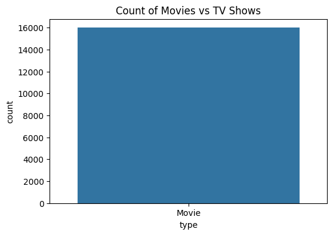

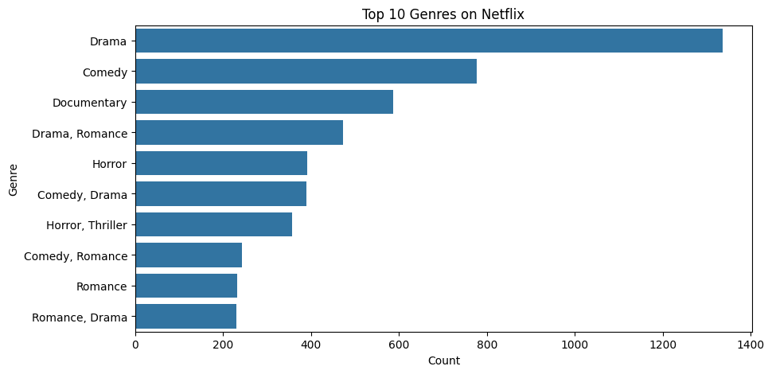

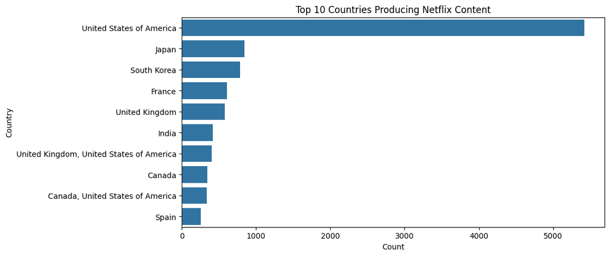

```python
import matplotlib.pyplot as plt
import seaborn as sns

# ---------- Numeric Column: Duration ----------
plt.figure(figsize=(8,5))
sns.histplot(df['duration'], bins=30, kde=True)
plt.title('Distribution of Movie/Show Duration')
plt.xlabel('Duration')
plt.ylabel('Count')
plt.show()

# ---------- Categorical Column: Type ----------
plt.figure(figsize=(6,4))
sns.countplot(x='type', data=df)
plt.title('Count of Movies vs TV Shows')
plt.show()

# ---------- Top 10 Genres ----------
top_genres = df['genres'].value_counts().head(10)
plt.figure(figsize=(10,5))
sns.barplot(x=top_genres.values, y=top_genres.index)
plt.title('Top 10 Genres on Netflix')
plt.xlabel('Count')
plt.ylabel('Genre')
plt.show()

# ---------- Top 10 Countries ----------
top_countries = df['country'].value_counts().head(10)
plt.figure(figsize=(10,5))
sns.barplot(x=top_countries.values, y=top_countries.index)
plt.title('Top 10 Countries Producing Netflix Content')
plt.xlabel('Count')
plt.ylabel('Country')
plt.show()
```

Top Categories

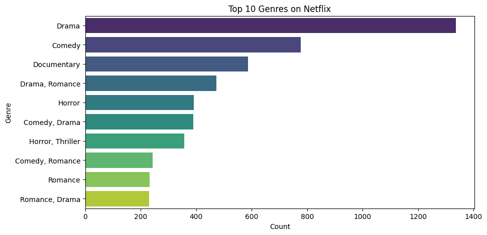

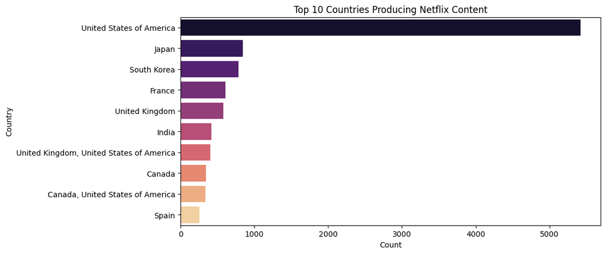

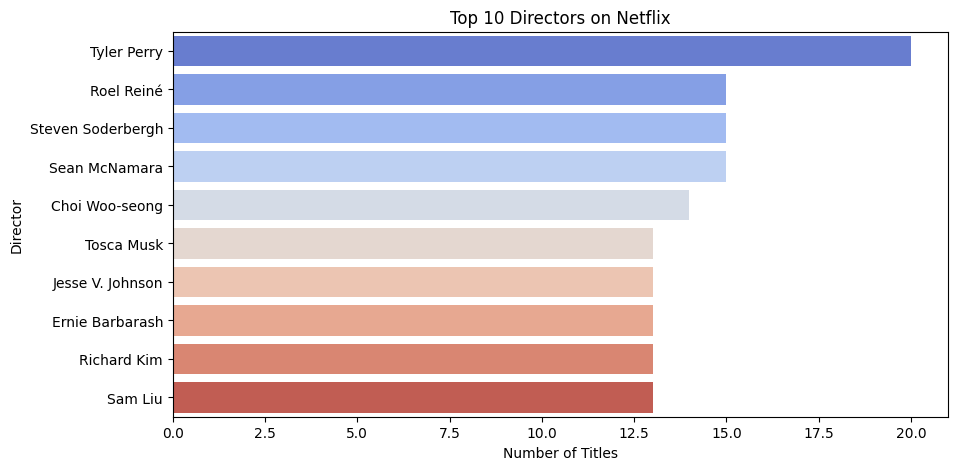

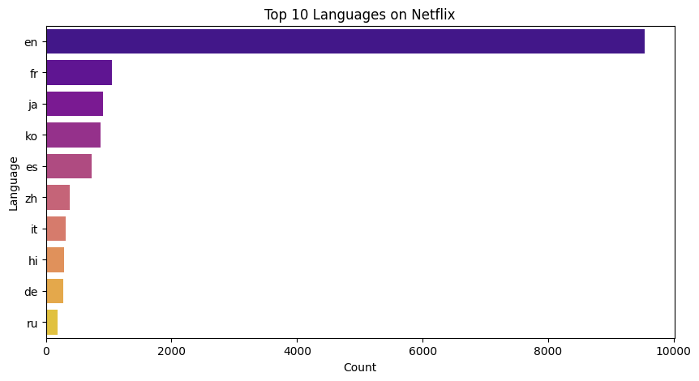

```python
import matplotlib.pyplot as plt
import seaborn as sns

# ---------- Top 10 Genres ----------
top_genres = df['genres'].value_counts().head(10)
plt.figure(figsize=(10,5))
sns.barplot(x=top_genres.values, y=top_genres.index, palette="viridis")
plt.title('Top 10 Genres on Netflix')
plt.xlabel('Count')
plt.ylabel('Genre')
plt.show()

# ---------- Top 10 Countries ----------
top_countries = df['country'].value_counts().head(10)
plt.figure(figsize=(10,5))
sns.barplot(x=top_countries.values, y=top_countries.index, palette="magma")
plt.title('Top 10 Countries Producing Netflix Content')
plt.xlabel('Count')
plt.ylabel('Country')
plt.show()

# ---------- Top 10 Directors ----------
top_directors = df['director'].value_counts().head(10)
plt.figure(figsize=(10,5))
sns.barplot(x=top_directors.values, y=top_directors.index, palette="coolwarm")
plt.title('Top 10 Directors on Netflix')
plt.xlabel('Number of Titles')
plt.ylabel('Director')
plt.show()

# ---------- Top 10 Languages ----------
top_languages = df['language'].value_counts().head(10)
plt.figure(figsize=(10,5))
sns.barplot(x=top_languages.values, y=top_languages.index, palette="plasma")
plt.title('Top 10 Languages on Netflix')
plt.xlabel('Count')
plt.ylabel('Language')
plt.show()
```

Identification of potential issues (missing data, outliers, inconsistent formats)

```
Missing values per column:

show_id             0
type                0
title               0
director          132
cast              204
country           466
date_added          0
release_year        0
rating              0
duration        16000
genres            107
language            0
description       132
popularity          0
vote_count          0
vote_average        0
budget              0
revenue             0
year_added          0
dtype: int64

Percentage of missing values per column:

show_id           0.00000
type              0.00000
title             0.00000
director          0.82500
cast              1.27500
country           2.91250
date_added        0.00000
release_year      0.00000
rating            0.00000
duration        100.00000
genres            0.66875
language          0.00000
description       0.82500
popularity        0.00000
vote_count        0.00000
vote_average      0.00000
budget            0.00000
revenue           0.00000
year_added        0.00000
dtype: float64
```

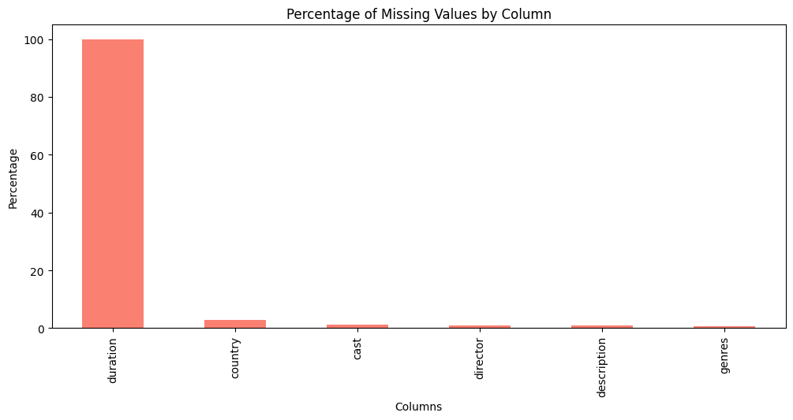

```python
import matplotlib.pyplot as plt

# ---------- Count of missing values per column ----------
missing_counts = df.isnull().sum()
print("Missing values per column:\n")
print(missing_counts)

# ---------- Percentage of missing values per column ----------
missing_percent = (df.isnull().sum() / len(df)) * 100
print("\nPercentage of missing values per column:\n")
print(missing_percent)

# ---------- Bar chart of missing percentages ----------
plt.figure(figsize=(12,5))
missing_percent[missing_percent > 0].sort_values(ascending=False).plot(kind='bar', color='salmon')
plt.title('Percentage of Missing Values by Column')
plt.ylabel('Percentage')
plt.xlabel('Columns')
plt.show()
```

Note: duration should be removed. Other columns should be imputed.

Ratings Analysis

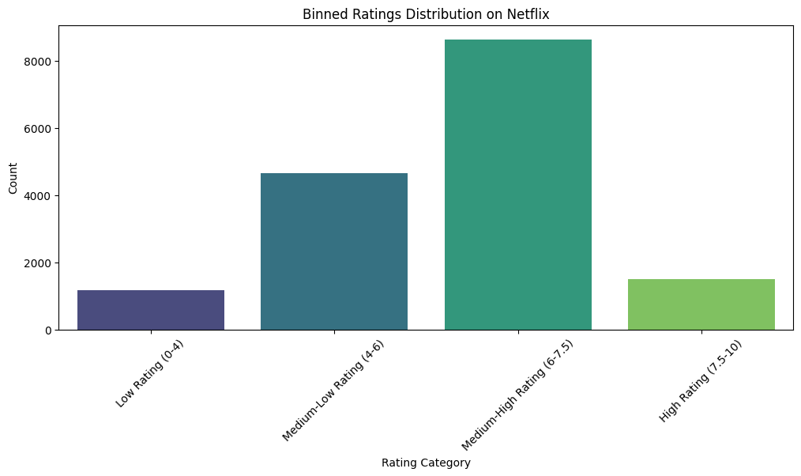

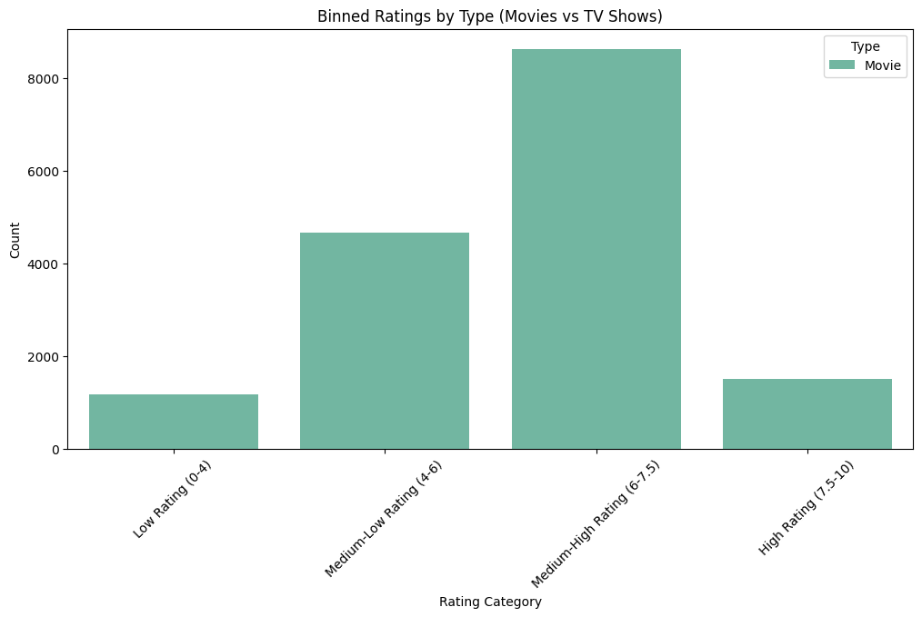

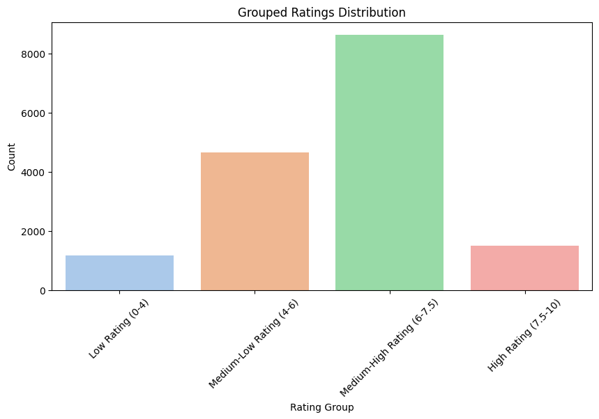

```python
import matplotlib.pyplot as plt
import seaborn as sns
import pandas as pd

# Bin the numeric 'rating' (vote_average) into categories for better legibility
bins = [0, 4, 6, 7.5, 10]
labels = ['Low Rating (0-4)', 'Medium-Low Rating (4-6)', 'Medium-High Rating (6-7.5)', 'High Rating (7.5-10)']
df['rating_grouped'] = pd.cut(df['rating'], bins=bins, labels=labels, right=False, include_lowest=True)

# ---------------------------------------------------
# 1️⃣ Barplot: Binned Ratings Distribution
# ---------------------------------------------------
plt.figure(figsize=(12,5))
sns.countplot(x='rating_grouped', data=df, order=labels, palette='viridis')
plt.title('Binned Ratings Distribution on Netflix')
plt.xlabel('Rating Category')
plt.ylabel('Count')
plt.xticks(rotation=45)
plt.show()


# ---------------------------------------------------
# 2️⃣ Binned Ratings Distribution by Type (Movie vs TV Show)
# ---------------------------------------------------
plt.figure(figsize=(12,6))
sns.countplot(x='rating_grouped', hue='type', data=df,
              order=labels,
              palette='Set2')
plt.title('Binned Ratings by Type (Movies vs TV Shows)')
plt.xlabel('Rating Category')
plt.ylabel('Count')
plt.xticks(rotation=45)
plt.legend(title='Type')
plt.show()


# ---------------------------------------------------
# 3️⃣ Grouped Rating Barplot (same as 1, for consistency with original notebook structure)
# ---------------------------------------------------
plt.figure(figsize=(10,5))
sns.countplot(x='rating_grouped', data=df,
              order=labels,
              palette='pastel')
plt.title('Grouped Ratings Distribution')
plt.xlabel('Rating Group')
plt.ylabel('Count')
plt.xticks(rotation=45)
plt.show()
```

Popularity, Votes, and Revenue

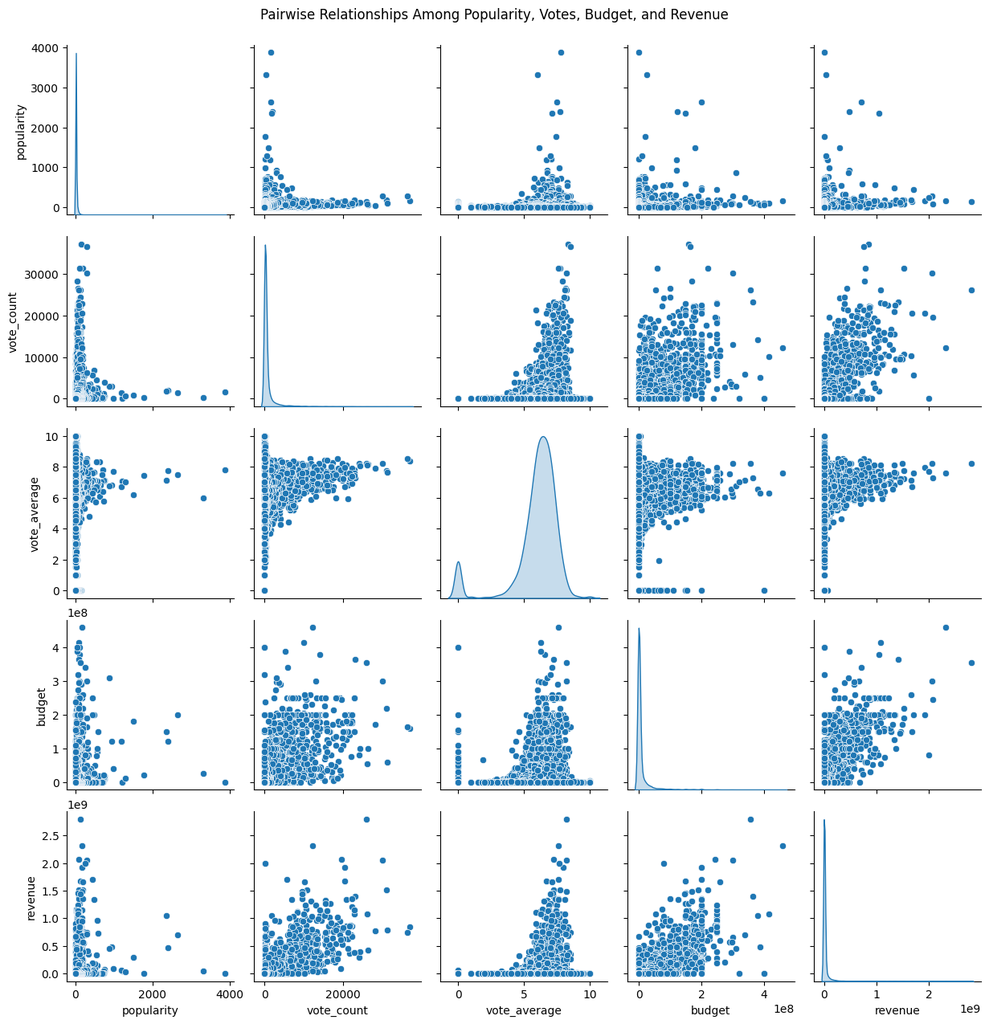

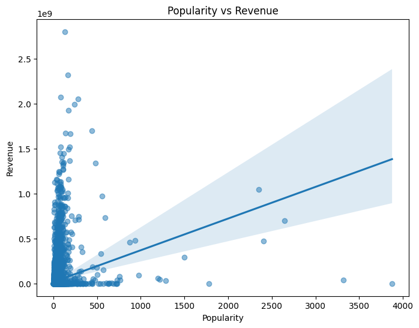

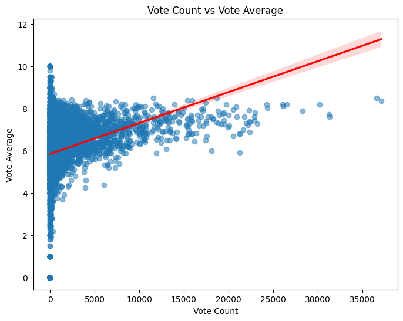

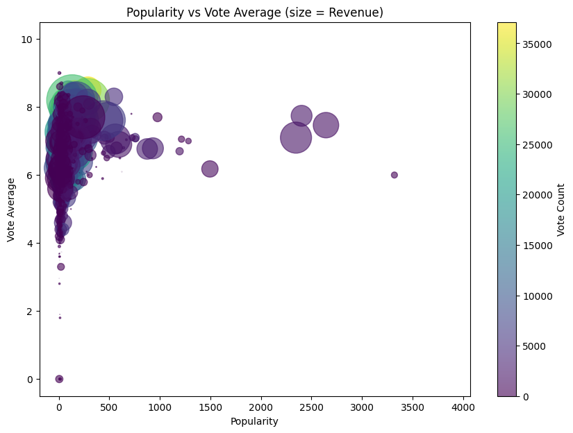

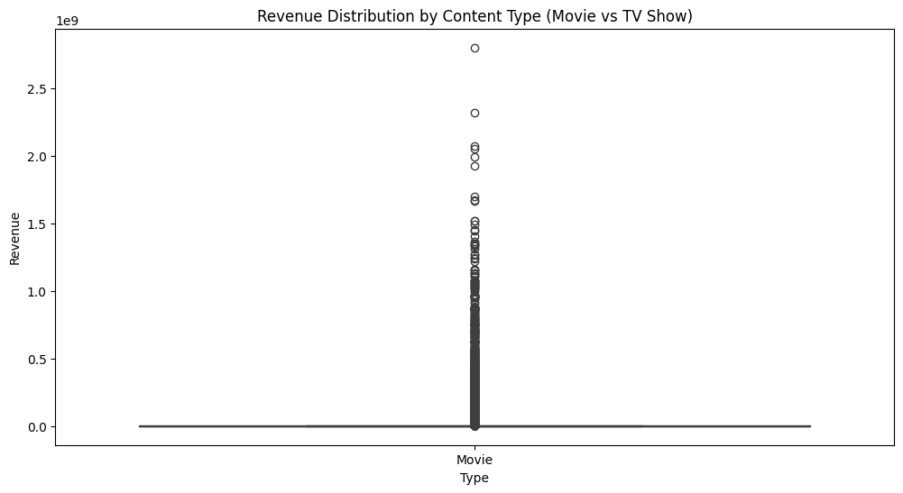

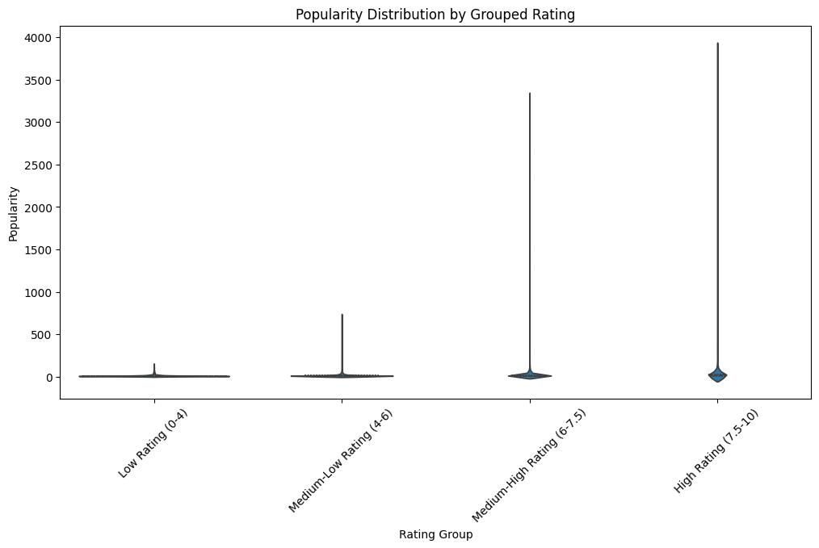

```python
import matplotlib.pyplot as plt
import seaborn as sns
import pandas as pd

# Redefine 'rating_grouped' using the 4 bins, ensuring consistency with previous plots
bins = [0, 4, 6, 7.5, 10]
labels = ['Low Rating (0-4)', 'Medium-Low Rating (4-6)', 'Medium-High Rating (6-7.5)', 'High Rating (7.5-10)']
df['rating_grouped'] = pd.cut(df['rating'], bins=bins, labels=labels, right=False, include_lowest=True)

numeric_cols = ['popularity', 'vote_count', 'vote_average', 'budget', 'revenue']

# ---------- 1′‸ Pairplot of Numeric Columns ----------
sns.pairplot(df[numeric_cols], diag_kind='kde')
plt.suptitle('Pairwise Relationships Among Popularity, Votes, Budget, and Revenue', y=1.02)
plt.show()

# ---------- 2′‸ Scatter Plot with Regression: Popularity vs Revenue ----------
plt.figure(figsize=(8,6))
sns.regplot(x='popularity', y='revenue', data=df, scatter_kws={'alpha':0.5})
plt.title('Popularity vs Revenue')
plt.xlabel('Popularity')
plt.ylabel('Revenue')
plt.show()

# ---------- 3′‸ Scatter Plot with Regression: Vote Count vs Vote Average ----------
plt.figure(figsize=(8,6))
sns.regplot(x='vote_count', y='vote_average', data=df, scatter_kws={'alpha':0.5}, line_kws={'color':'red'})
plt.title('Vote Count vs Vote Average')
plt.xlabel('Vote Count')
plt.ylabel('Vote Average')
plt.show()

# ---------- 4′‸ Bubble Plot: Popularity vs Vote Average (size = Revenue, color = Vote Count) ----------
plt.figure(figsize=(10,7))
plt.scatter(
    df['popularity'],
    df['vote_average'],
    s=df['revenue'].fillna(0) / 1e6,  # scale down revenue for point size, fill NaN with 0
    alpha=0.6,
    c=df['vote_count'].fillna(0),     # color by vote_count
    cmap='viridis'
)
plt.colorbar(label='Vote Count')
plt.title('Popularity vs Vote Average (size = Revenue)')
plt.xlabel('Popularity')
plt.ylabel('Vote Average')
plt.show()

# ---------- 5′‸ Boxplot: Revenue by Type ----------
plt.figure(figsize=(12,6))
sns.boxplot(x='type', y='revenue', data=df)
plt.title('Revenue Distribution by Content Type (Movie vs TV Show)')
plt.xlabel('Type')
plt.ylabel('Revenue')
plt.show()

# ---------- 6′‸ Violin Plot: Popularity by Grouped Ratings ----------
plt.figure(figsize=(12,6))
sns.violinplot(x='rating_grouped', y='popularity', data=df, order=labels, inner='quartile')
plt.title('Popularity Distribution by Grouped Rating')
plt.xlabel('Rating Group')
plt.ylabel('Popularity')
plt.xticks(rotation=45)
plt.show()
```

Multi-Variable Analysis

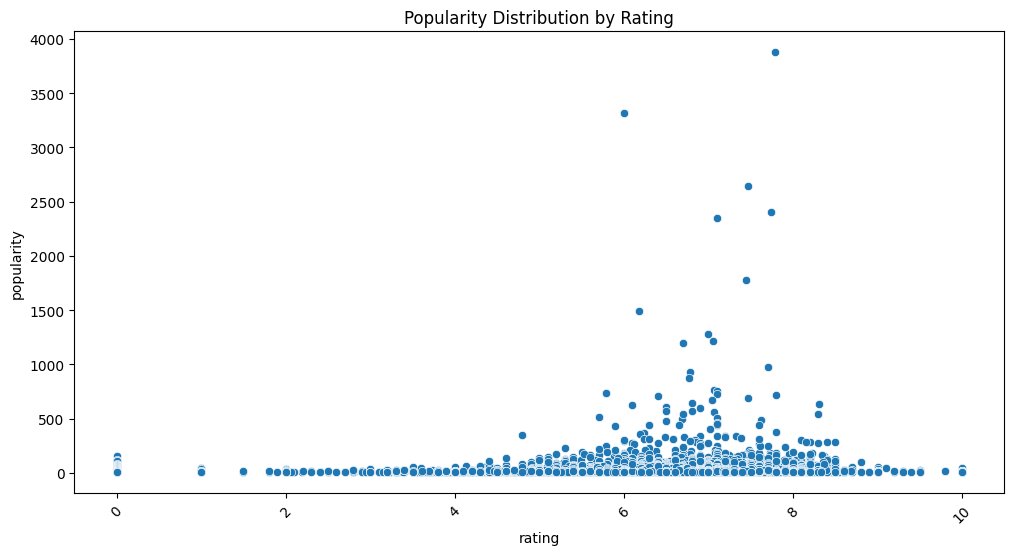

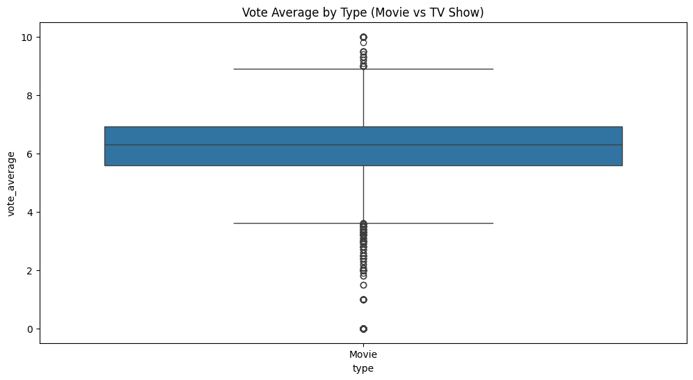

```python
plt.figure(figsize=(12,6))
sns.scatterplot(x='rating', y='popularity', data=df)
plt.title('Popularity Distribution by Rating')
plt.xticks(rotation=45)
plt.show()

plt.figure(figsize=(12,6))
sns.boxplot(x='type', y='vote_average', data=df)
plt.title('Vote Average by Type (Movie vs TV Show)')
plt.show()
```

Content Type Analysis

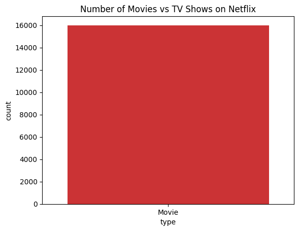

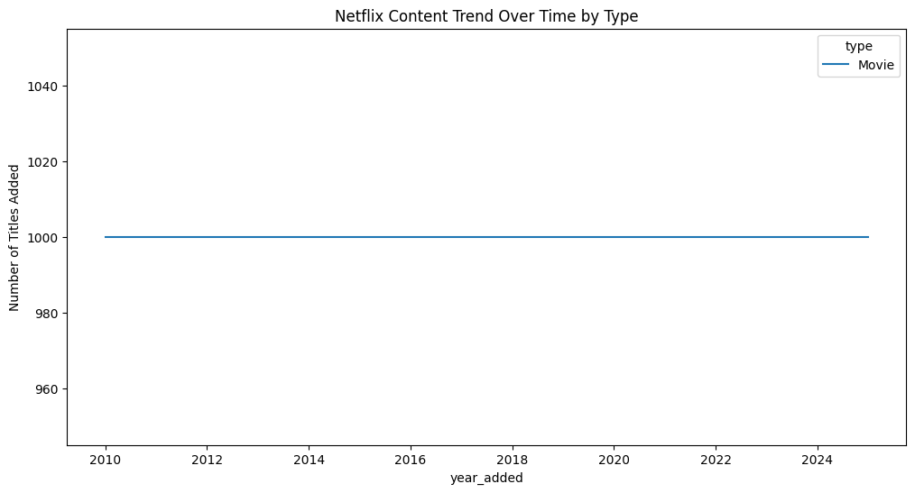

```python
# Convert date_added to datetime
df['date_added'] = pd.to_datetime(df['date_added'], errors='coerce')

# Extract year
df['year_added'] = df['date_added'].dt.year
sns.countplot(x='type', data=df, palette='Set1')
plt.title('Number of Movies vs TV Shows on Netflix')
plt.show()

type_year = df.groupby(['year_added', 'type']).size().unstack()
type_year.plot(kind='line', figsize=(12,6))
plt.title('Netflix Content Trend Over Time by Type')
plt.ylabel('Number of Titles Added')
plt.show()
```

Country Analysis

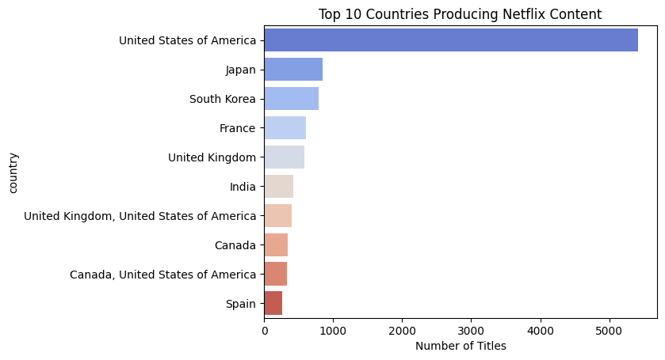

[figure not shown]

```python
top_countries = df['country'].value_counts().head(10)
sns.barplot(x=top_countries.values, y=top_countries.index, palette='coolwarm')
plt.title('Top 10 Countries Producing Netflix Content')
plt.xlabel('Number of Titles')
plt.show()
country_type = df.groupby(['country','type']).size().unstack().fillna(0)
country_type.head(10).plot(kind='bar', stacked=True, figsize=(12,6))
plt.title('Top Countries by Content Type')
plt.ylabel('Number of Titles')
plt.show()
```

Genre Analysis

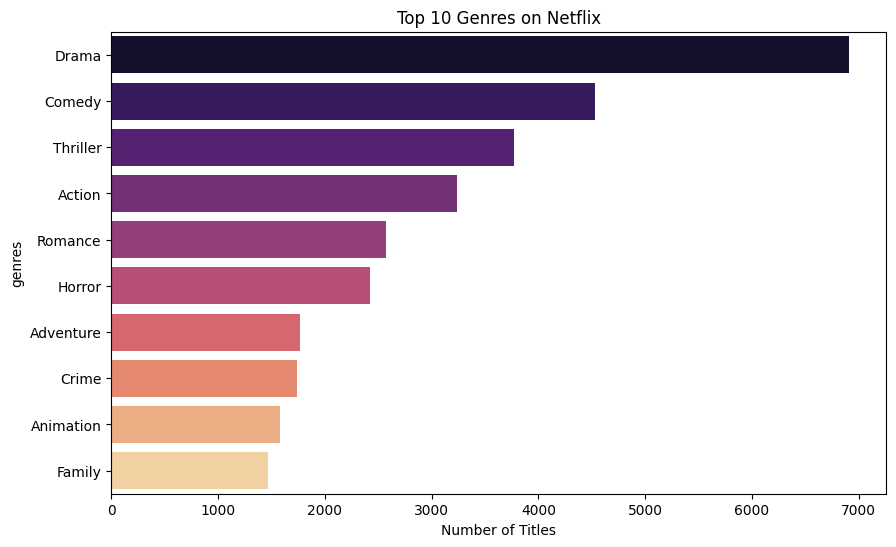

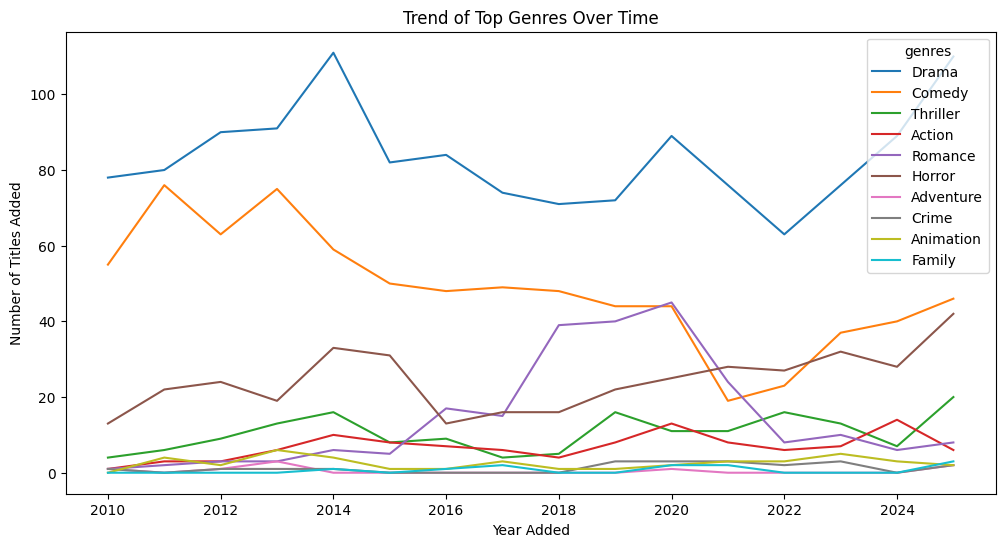

```python
import matplotlib.pyplot as plt
import seaborn as sns

# ---------- Top Genres Overall ----------
genre_series = df['genres'].dropna().str.split(',').explode().str.strip()  # strip spaces
top_genres = genre_series.value_counts().head(10)

plt.figure(figsize=(10,6))
sns.barplot(x=top_genres.values, y=top_genres.index, palette='magma')
plt.title('Top 10 Genres on Netflix')
plt.xlabel('Number of Titles')
plt.show()

# ---------- Trend of Top Genres Over Time ----------
genre_year = df.dropna(subset=['genres']).copy()
genre_year = genre_year.explode('genres')
genre_year['genres'] = genre_year['genres'].str.strip()  # strip spaces
genre_year = genre_year.groupby(['year_added','genres']).size().unstack().fillna(0)

# Only plot top genres
genre_year[top_genres.index].plot(figsize=(12,6))
plt.title('Trend of Top Genres Over Time')
plt.ylabel('Number of Titles Added')
plt.xlabel('Year Added')
plt.show()
```

Language Analysis

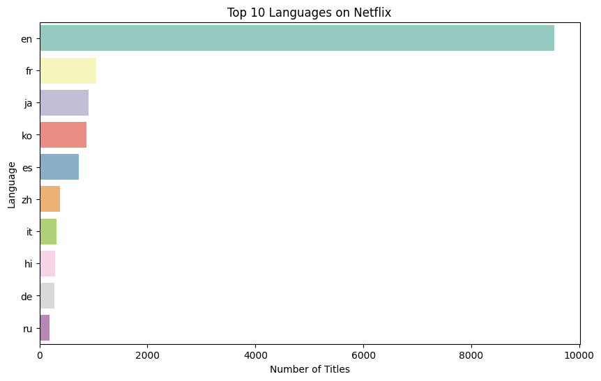

```python
top_languages = df['language'].value_counts().head(10)

plt.figure(figsize=(10,6))
sns.barplot(x=top_languages.values, y=top_languages.index, palette='Set3')
plt.title('Top 10 Languages on Netflix')
plt.xlabel('Number of Titles')
plt.ylabel('Language')
plt.show()
```

Correlation analysis

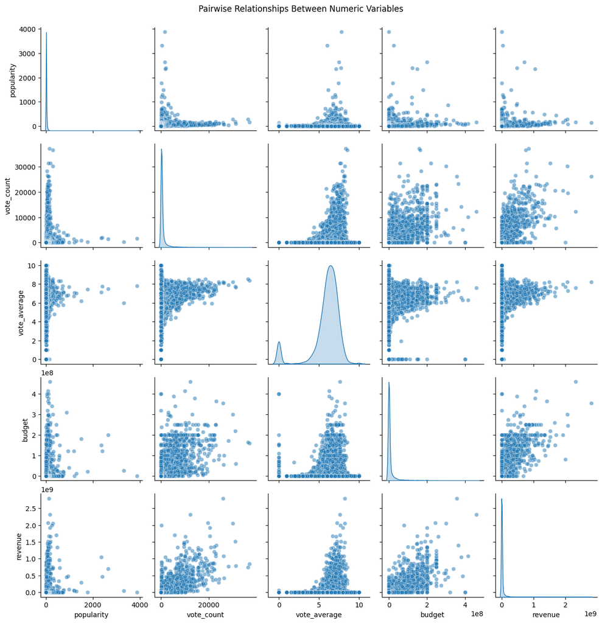

```python
import seaborn as sns
import matplotlib.pyplot as plt

numeric_cols = ['popularity', 'vote_count', 'vote_average', 'budget', 'revenue']

sns.pairplot(df[numeric_cols], kind='scatter', diag_kind='kde', plot_kws={'alpha':0.5})
plt.suptitle('Pairwise Relationships Between Numeric Variables', y=1.02)
plt.show()
```

# 6. Data cleaning & Preprocessing

**Handling missing values, duplicates, and outliers**

Duplicates

```python
# -----------------------------
# Remove duplicates safely
# -----------------------------
list_columns = []

for col in df.columns:
    series = df[col]
    # Convert Categorical to object temporarily
    if str(series.dtype) == 'category':
        series = series.astype('object')
    # Check if any value is a list
    if series.apply(lambda x: isinstance(x, list)).any():
        list_columns.append(col)

print("Columns containing lists (excluded from duplicate check):", list_columns)

# Only use hashable columns for duplicates
hashable_cols = [col for col in df.columns if col not in list_columns]
df = df.drop_duplicates(subset=hashable_cols)

# Reset index
df = df.reset_index(drop=True)

# Quick check
print("Shape after cleaning:", df.shape)
print("Any duplicates left?", df.drop(columns=list_columns).duplicated().sum())
```

```
Columns containing lists (excluded from duplicate check): []
Shape after cleaning: (16000, 20)
Any duplicates left? 0
```

Handle Missing Values

```python
# Check missing values
missing_counts = df.isnull().sum()
missing_percent = (df.isnull().sum() / len(df)) * 100
print("Missing values per column:\n", missing_counts)
print("\nPercentage of missing values:\n", missing_percent)

# Fill missing values
numeric_cols = ['popularity', 'vote_count', 'vote_average', 'budget', 'revenue', 'release_year']
categorical_cols = ['type', 'rating_grouped', 'country', 'language', 'genres', 'description', 'director', 'cast'] # Added description, director, cast to handle all NaNs

for col in numeric_cols:
    if col in df.columns:
        df[col] = df[col].fillna(0)

for col in categorical_cols:
    if col in df.columns:
        # If the column is categorical, add 'Unknown' to its categories first
        if pd.api.types.is_categorical_dtype(df[col]):
            if 'Unknown' not in df[col].cat.categories:
                df[col] = df[col].cat.add_categories('Unknown')
        df[col] = df[col].fillna('Unknown')
```

```
Missing values per column:
 show_id               0
type                  0
title                 0
director            132
cast                204
country             466
date_added            0
release_year          0
rating                0
duration          16000
genres              107
language              0
description         132
popularity            0
vote_count            0
vote_average          0
budget                0
revenue               0
year_added            0
rating_grouped       35
dtype: int64

Percentage of missing values:
 show_id             0.00000
type                0.00000
title               0.00000
director            0.82500
cast                1.27500
country             2.91250
date_added          0.00000
release_year        0.00000
rating              0.00000
duration          100.00000
genres              0.66875
language            0.00000
description         0.82500
popularity          0.00000
vote_count          0.00000
vote_average        0.00000
budget              0.00000
revenue             0.00000
year_added          0.00000
rating_grouped      0.21875
dtype: float64
```

Convert Dates & Extract Year Added

```python
df['date_added'] = pd.to_datetime(df['date_added'], errors='coerce')
df['year_added'] = df['date_added'].dt.year
```

Standardize Duration

```python
# Convert duration column to string first (safe for NaN)
df['duration_str'] = df['duration'].astype(str)

# Extract numeric values for movies/TV
df['duration_num'] = df['duration_str'].str.extract(r'(\d+)').astype(float)

# For TV shows, create a 'seasons' column if "Season" in original duration
df['seasons'] = df.apply(lambda x: float(x['duration_num']) if 'Season' in str(x['duration']) else 0, axis=1)

# Optional: drop temporary column
df = df.drop(columns=['duration_str'])

# Quick check
df[['duration', 'duration_num', 'seasons']].head(10)
```

|  | duration | duration_num | seasons |
| --- | --- | --- | --- |
| 0 | NaN | NaN | 0 |
| 1 | NaN | NaN | 0 |
| 2 | NaN | NaN | 0 |
| 3 | NaN | NaN | 0 |
| 4 | NaN | NaN | 0 |
| 5 | NaN | NaN | 0 |
| 6 | NaN | NaN | 0 |
| 7 | NaN | NaN | 0 |
| 8 | NaN | NaN | 0 |
| 9 | NaN | NaN | 0 |

Clean & Split Genres

```python
# Convert genres string to a list and strip spaces
df['genres_list'] = df['genres'].dropna().str.split(',').apply(lambda x: [g.strip() for g in x])
```

Convert Other Categorical Columns

```python
categorical_prep = ['type', 'rating_grouped', 'country', 'language']
for col in categorical_prep:
    if col in df.columns:
        df[col] = df[col].astype('category')
```

Final Check

```python
print("\nShape after cleaning:", df.shape)
print("Columns now:", df.columns.tolist())

# Check duplicates, ignoring 'genres_list' (unhashable type)
print("Any duplicates left?", df.drop(columns=['genres_list']).duplicated().sum())
```

```
Shape after cleaning: (16000, 23)
Columns now: ['show_id', 'type', 'title', 'director', 'cast', 'country', 'date_added', 'release_year', 'rating', 'duration', 'genres', 'language', 'description', 'popularity', 'vote_count', 'vote_average', 'budget', 'revenue', 'year_added', 'rating_grouped', 'duration_num', 'seasons', 'genres_list']
Any duplicates left? 0
```

Show descriptive statistics

```python
# =========================
# Descriptive Statistics for Cleaned Data
# =========================

import pandas as pd

# Separate numeric and categorical columns
numeric_cols = df.select_dtypes(include=['int64', 'float64']).columns.tolist()
categorical_cols = df.select_dtypes(include=['object', 'category']).columns.tolist()

# Identify columns that contain lists
list_cols = []
for col in categorical_cols:
    temp = df[col].astype(object)  # avoid Categorical dtype issues
    if temp.apply(lambda x: isinstance(x, list)).any():
        list_cols.append(col)

# Columns safe for categorical analysis (exclude list columns)
categorical_cols_clean = [col for col in categorical_cols if col not in list_cols]

print("===== Numeric Columns Summary =====\n")
print(df[numeric_cols].describe())

print("\n===== Categorical Columns Summary =====\n")
for col in categorical_cols_clean:
    print(f"Column: {col}")
    print("Number of unique values:", df[col].nunique())
    print("Top 5 most frequent values:")
    print(df[col].value_counts(dropna=False).head(5))
    print("-"*40)

print("\n===== List Columns Summary (like genres_list) =====\n")
for col in list_cols:
    # Flatten all lists into a single series
    all_items = df[col].dropna().explode()
    print(f"Column: {col}")
    print("Number of unique items:", all_items.nunique())
    print("Top 5 most frequent items:")
    print(all_items.value_counts().head(5))
    print("-"*40)
```

```
===== Numeric Columns Summary =====

            show_id  release_year        rating  duration    popularity  \
count  1.600000e+04  16000.000000  16000.000000       0.0  16000.000000
mean   5.266582e+05   2017.500000      5.956368       NaN     20.384728
std    3.794427e+05      4.609916      1.754741       NaN     68.610033
min    1.890000e+02   2010.000000      0.000000       NaN      3.860000
25%    2.257258e+05   2013.750000      5.600000       NaN      7.840750
50%    4.468170e+05   2017.500000      6.300000       NaN     10.913500
75%    7.739808e+05   2021.250000      6.923000       NaN     17.336500
max    1.440471e+06   2025.000000     10.000000       NaN   3876.006000

         vote_count  vote_average        budget       revenue  duration_num  \
count  16000.000000  16000.000000  1.600000e+04  1.600000e+04           0.0
mean     718.656125      5.956368  8.766792e+06  2.446308e+07           NaN
std     2080.198316      1.754741  2.912450e+07  1.116977e+08           NaN
min        0.000000      0.000000  0.000000e+00  0.000000e+00           NaN
25%       53.000000      5.600000  0.000000e+00  0.000000e+00           NaN
50%      138.000000      6.300000  0.000000e+00  0.000000e+00           NaN
75%      422.000000      6.923000  2.200000e+06  1.654473e+06           NaN
max    37119.000000     10.000000  4.600000e+08  2.799439e+09           NaN

       seasons
count  16000.0
mean       0.0
std        0.0
min        0.0
25%        0.0
50%        0.0
75%        0.0
max        0.0

===== Categorical Columns Summary =====

Column: type
Number of unique values: 1
Top 5 most frequent values:
type
Movie    16000
Name: count, dtype: int64
```

[output cut: 88 more lines]

```
----------------------------------------

===== List Columns Summary (like genres_list) =====

Column: genres_list
Number of unique items: 19
Top 5 most frequent items:
genres_list
Drama       6910
Comedy      4533
Thriller    3769
Action      3239
Romance     2571
Name: count, dtype: int64
----------------------------------------
```

After cleaning: Check the shape of the dataset, Check the columns and their types, Check for missing values, Check duplicates, Quick descriptive statistics, Preview the dataset

```python
# -----------------------------
# 1️⃣ Remove duplicates safely (fix for categorical columns)
# -----------------------------

list_columns = []

for col in df.columns:
    # Temporarily convert to object if categorical
    series = df[col]
    if series.dtype.name == 'category':
        series = series.astype('object')

    # Check if any value is a list
    if series.apply(lambda x: isinstance(x, list)).any():
        list_columns.append(col)

print("Columns containing lists (excluded from duplicate check):", list_columns)

# Only use hashable columns for duplicates
hashable_cols = [col for col in df.columns if col not in list_columns]

df = df.drop_duplicates(subset=hashable_cols)
print("Shape after removing duplicates:", df.shape)
```

```
Columns containing lists (excluded from duplicate check): ['genres_list']
Shape after removing duplicates: (16000, 23)
```

```python
import pandas as pd
import numpy as np

# ----------------------------------------------------
# 1️⃣ Load Data
# ----------------------------------------------------

df = pd.read_csv(csv_url)

print("Initial shape:", df.shape)
print("Initial columns:", df.columns.tolist())
print("\n")


# ----------------------------------------------------
# 2️⃣ Basic Cleaning: strip column names, handle objects
# ----------------------------------------------------
df.columns = df.columns.str.strip().str.lower().str.replace(" ", "_")

# Convert empty strings to NaN
df.replace("", np.nan, inplace=True)


# ----------------------------------------------------
# 3️⃣ Identify list-like columns and convert safely
# ----------------------------------------------------
list_columns = []

for col in df.columns:
    # If ANY row contains a list → treat the whole column as list-like
    if df[col].apply(lambda x: isinstance(x, list)).any():
        list_columns.append(col)

print("List columns detected:", list_columns)

# Convert list columns to strings for safety
for col in list_columns:
    df[col] = df[col].apply(lambda x: ",".join(x) if isinstance(x, list) else x)


# ----------------------------------------------------
# 4️⃣ Handle missing values (numeric + categorical)
# ----------------------------------------------------
numeric_cols = df.select_dtypes(include=['int64','float64']).columns
categorical_cols = df.select_dtypes(include=['object']).columns

# Fill numeric
df[numeric_cols] = df[numeric_cols].fillna(df[numeric_cols].median())

# Fill categorical
df[categorical_cols] = df[categorical_cols].fillna("Unknown")


# ----------------------------------------------------
# 5️⃣ Safe Duplicate Removal
# (after converting list columns to strings)
# ----------------------------------------------------
duplicate_count = df.duplicated().sum()
print("Duplicate rows found:", duplicate_count)

df = df.drop_duplicates()
print("Shape after removing duplicates:", df.shape)
print("\n")


# ----------------------------------------------------
# 6️⃣ Create df_clean for modeling
# ----------------------------------------------------
df_clean = df.copy()
print("df_clean READY with shape:", df_clean.shape)
print("\n")


# ----------------------------------------------------
# 7️⃣ Diagnostics: Missing, stats, preview
# ----------------------------------------------------
print("Missing Values:\n")
missing_df = pd.DataFrame({
    "Missing Count": df_clean.isnull().sum(),
    "Missing %": (df_clean.isnull().mean()*100).round(2)
})
print(missing_df)
print("\n")

print("Numeric Summary:\n")
print(df_clean.describe())
print("\n")

print("Categorical Summary:\n")
print(df_clean.describe(include="object"))
print("\n")

print("Data Preview:\n")
print(df_clean.head())
```

```
Initial shape: (16000, 18)
Initial columns: ['show_id', 'type', 'title', 'director', 'cast', 'country', 'date_added', 'release_year', 'rating', 'duration', 'genres', 'language', 'description', 'popularity', 'vote_count', 'vote_average', 'budget', 'revenue']


List columns detected: []
Duplicate rows found: 0
Shape after removing duplicates: (16000, 18)


df_clean READY with shape: (16000, 18)


Missing Values:

              Missing Count  Missing %
show_id                   0        0.0
type                      0        0.0
title                     0        0.0
director                  0        0.0
cast                      0        0.0
country                   0        0.0
date_added                0        0.0
release_year              0        0.0
rating                    0        0.0
duration              16000      100.0
genres                    0        0.0
language                  0        0.0
description               0        0.0
popularity                0        0.0
vote_count                0        0.0
vote_average              0        0.0
budget                    0        0.0
revenue                   0        0.0


Numeric Summary:

            show_id  release_year        rating  duration    popularity  \
count  1.600000e+04  16000.000000  16000.000000       0.0  16000.000000
mean   5.266582e+05   2017.500000      5.956368       NaN     20.384728
```

[output cut: 68 more lines]

```
4       NaN          Fantasy, Adventure, Animation, Family       en

                                         description  popularity  vote_count  \
0  A bored and domesticated Shrek pacts with deal...     203.893        7449
1  Cobb, a skilled thief who commits corporate es...     156.242       37119
2  Harry, Ron and Hermione walk away from their l...     121.191       19327
3  Feisty teenager Rapunzel, who has long and mag...     111.762       11638
4  As the son of a Viking leader on the cusp of m...     110.044       13259

   vote_average     budget    revenue
0         6.380  165000000  752600867
1         8.369  160000000  839030630
2         7.744  250000000  954305868
3         7.600  260000000  592461732
4         7.800  165000000  494879471
```

# 7. Modeling Approach

**Rationale for model selection (why you chose each algorithm)**

**Description of 2–3 models to be tested**

For this project, we selected three distinct modeling approaches: classification, regression, and clustering. These models help us understand different aspects of Netflix content performance. Each model answers a different business question.

Logistic Regression (Classification: Predicting Hit Titles)

We picked logistic regression because it’s straightforward and easy to understand. Since our goal was to predict whether a title would be a hit or not, this model works well for binary outcomes. It also helps us see which features like genre, type, language, or release year actually increase the chances of a title being successful. This gives us a good baseline before trying more advanced models.

(Regression: Predicting Revenue) -

Revenue is a continuous number, and it can depend on many nonlinear factors such as budget, votes, or popularity. A random forest handles these kinds of complex relationships really well. It works even when there are lots of variables, and it can show us which features matter the most. This is useful for business teams because it highlights what actually drives revenue for Netflix.

K-Means Clustering Unsupervised: Grouping Performance Profiles

Netflix has a huge variety of content, so we also used clustering to find natural groups in the data. K-Means is simple and easy to interpret. After scaling features like revenue, budget, popularity, and votes, the model grouped the titles into different performance levels, such as high performing, mid performing, and low performing clusters. This helps Netflix understand overall content patterns, not just make predictions.

**Train/test split or cross-validation approach** For the supervised models, we split the data into 80% for training and 20% for testing, and we used stratification for the classification model so both classes were balanced. For the clustering model, we checked different k values and used the silhouette score and Davies Bouldin score to see which number of clusters worked best. Based on those results, we chose k = 4

# 8. Model Implementation

**Model 1: Regression Classification Model for Predicting Netflix “Hit” Titles**

```
Accuracy: 0.631875

Classification Report:
               precision    recall  f1-score   support

           0       0.64      0.65      0.64      1643
           1       0.62      0.62      0.62      1557

    accuracy                           0.63      3200
   macro avg       0.63      0.63      0.63      3200
weighted avg       0.63      0.63      0.63      3200
```

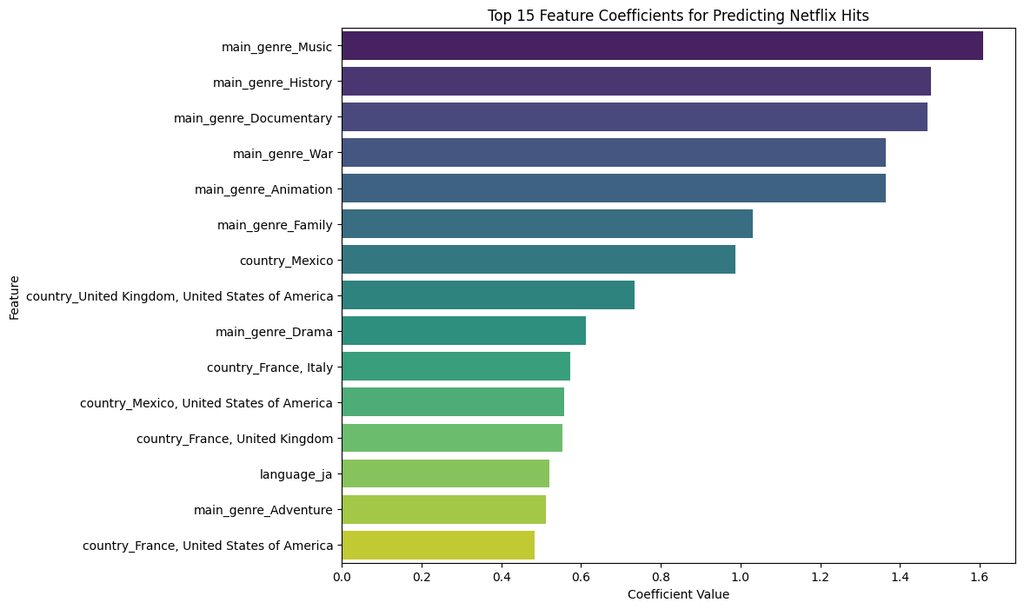

```python
# -----------------------------
# Netflix Hit Prediction
# -----------------------------
import pandas as pd
import numpy as np
from sklearn.model_selection import train_test_split
from sklearn.linear_model import LogisticRegression
from sklearn.metrics import accuracy_score, classification_report
import matplotlib.pyplot as plt
import seaborn as sns

# -----------------------------
# Use cleaned dataframe
# -----------------------------
df_model = df_clean.copy()

# -----------------------------
# Standardize duration & seasons
# -----------------------------
df_model['duration'] = df_model['duration'].astype(str)

df_model['duration_num'] = pd.to_numeric(
    df_model['duration'].str.extract(r'(\d+)')[0],
    errors='coerce'
)

def get_seasons(val):
    if isinstance(val, str) and "Season" in val:
        nums = [int(s) for s in val.split() if s.isdigit()]
        return nums[0] if nums else 0
    return 0

df_model['seasons'] = df_model['duration'].apply(get_seasons)

# -----------------------------
# Extract MAIN GENRE
# -----------------------------
df_model['genres'] = df_model['genres'].astype(str)

df_model['main_genre'] = df_model['genres'].apply(
    lambda x: x.split(',')[0].strip() if ',' in x else x
)

df_model['main_genre'] = df_model['main_genre'].replace("nan", "Unknown")
df_model['main_genre'] = df_model['main_genre'].fillna("Unknown")

# -----------------------------
# Create target variable
# -----------------------------
df_model['is_hit'] = (
    df_model['vote_average'] > df_model['vote_average'].median()
).astype(int)

# -----------------------------
# Select features
# -----------------------------
feature_cols = [
    'type', 'main_genre', 'language', 'country',
    'duration_num', 'seasons', 'release_year'
]

X = df_model[feature_cols].copy()
y = df_model['is_hit']

# -----------------------------
# FIX: Impute missing BEFORE encoding
# -----------------------------
# Fill categorical missing with "Unknown"
for col in ['type', 'main_genre', 'language', 'country']:
    X[col] = X[col].fillna("Unknown")

# Fill numeric missing with median
for col in ['duration_num', 'seasons', 'release_year']:
    X[col] = X[col].fillna(X[col].median())

# -----------------------------
# One-hot encode
# -----------------------------
X_encoded = pd.get_dummies(
    X,
    columns=['type', 'main_genre', 'language', 'country'],
    drop_first=True
)

# Double-check no NaNs remain
X_encoded = X_encoded.fillna(0)

# -----------------------------
# Train-test split
# -----------------------------
X_train, X_test, y_train, y_test = train_test_split(
    X_encoded, y, test_size=0.2, random_state=42, stratify=y
)

# -----------------------------
# Train Logistic Regression
# -----------------------------
model = LogisticRegression(max_iter=500)
model.fit(X_train, y_train)

# -----------------------------
# Evaluate model
# -----------------------------
y_pred = model.predict(X_test)

print("Accuracy:", accuracy_score(y_test, y_pred))
print("\nClassification Report:\n", classification_report(y_test, y_pred))

# -----------------------------
# Feature Importance
# -----------------------------
coef_df = pd.DataFrame({
    'feature': X_encoded.columns,
    'coefficient': model.coef_[0]
}).sort_values(by='coefficient', ascending=False)

plt.figure(figsize=(10,8))
sns.barplot(
    x='coefficient',
    y='feature',
    data=coef_df.head(15),
    palette='viridis'
)
plt.title('Top 15 Feature Coefficients for Predicting Netflix Hits')
plt.xlabel('Coefficient Value')
plt.ylabel('Feature')
plt.show()
```

**Model 2: Netflix Revenue Prediction Model**

```python
import pandas as pd
import numpy as np
from sklearn.model_selection import train_test_split
from sklearn.preprocessing import OneHotEncoder, StandardScaler
from sklearn.compose import ColumnTransformer
from sklearn.pipeline import Pipeline
from sklearn.ensemble import RandomForestRegressor
from sklearn.metrics import mean_squared_error, r2_score

# -----------------------------
# 1️⃣ Define features and target
# -----------------------------
numeric_features = ['release_year', 'popularity', 'vote_count', 'vote_average', 'budget']
categorical_features = ['type', 'rating', 'language']

target = 'revenue'

X = df_clean[numeric_features + categorical_features]
y = df_clean[target]

# -----------------------------
# 2️⃣ Split into train/test
# -----------------------------
X_train, X_test, y_train, y_test = train_test_split(
    X, y, test_size=0.2, random_state=42
)

# -----------------------------
# 3️⃣ Preprocessing
# -----------------------------
numeric_transformer = StandardScaler()
categorical_transformer = OneHotEncoder(handle_unknown='ignore')

preprocessor = ColumnTransformer(
    transformers=[
        ('num', numeric_transformer, numeric_features),
        ('cat', categorical_transformer, categorical_features)
    ]
)

# -----------------------------
# 4️⃣ Pipeline with model
# -----------------------------
model = Pipeline(steps=[
    ('preprocessor', preprocessor),
    ('regressor', RandomForestRegressor(n_estimators=100, random_state=42))
])

# -----------------------------
# 5️⃣ Train the model
# -----------------------------
model.fit(X_train, y_train)

# -----------------------------
# 6️⃣ Predict & evaluate
# -----------------------------
y_pred = model.predict(X_test)

mse = mean_squared_error(y_test, y_pred)
r2 = r2_score(y_test, y_pred)

print(f"Mean Squared Error: {mse:.2e}")
print(f"R^2 Score: {r2:.3f}")

# -----------------------------
# ✅ Feature importance (numeric only, approximate)
# -----------------------------
# Get numeric feature importances from the random forest
importances = model.named_steps['regressor'].feature_importances_
feature_names = numeric_features + list(model.named_steps['preprocessor']
                                        .named_transformers_['cat']
                                        .get_feature_names_out(categorical_features))

importance_df = pd.DataFrame({
    'feature': feature_names,
    'importance': importances
}).sort_values(by='importance', ascending=False)

print("\nFeature Importances:\n", importance_df)
```

```
Mean Squared Error: 3.05e+15
R^2 Score: 0.761

Feature Importances:
            feature  importance
4           budget    0.400810
2       vote_count    0.383436
1       popularity    0.072308
0     release_year    0.028621
3     vote_average    0.022797
...            ...         ...
377   rating_5.529    0.000000
381   rating_5.538    0.000000
402    rating_5.59    0.000000
1100  rating_6.673    0.000000
386   rating_5.552    0.000000

[1956 rows x 2 columns]
```

**Model 3: KMeans Clustering to Explore Characteristics of Best Performing Groups**

```python
import pandas as pd
import numpy as np
from sklearn.cluster import KMeans
from sklearn.preprocessing import StandardScaler, OneHotEncoder
from sklearn.compose import ColumnTransformer
from sklearn.pipeline import Pipeline
from sklearn.metrics import silhouette_score, davies_bouldin_score
import matplotlib.pyplot as plt
import seaborn as sns

# Select features relevant for clustering
numeric_features_for_clustering = ['release_year', 'rating', 'popularity', 'vote_count', 'vote_average', 'budget', 'revenue']
categorical_features_for_clustering = ['type']

# Create a preprocessor to handle both numeric and categorical features
preprocessor = ColumnTransformer(
    transformers=[
        ('num', StandardScaler(), numeric_features_for_clustering),
        ('cat', OneHotEncoder(handle_unknown='ignore'), categorical_features_for_clustering)
    ],
    remainder='drop' # Drop columns not specified
)

# Apply preprocessing to df_clean
X_clust = df_clean[numeric_features_for_clustering + categorical_features_for_clustering].copy()

# Fit and transform the data
df_scaled_array = preprocessor.fit_transform(X_clust)

# Get feature names after one-hot encoding for the scaled DataFrame
categorical_feature_names = preprocessor.named_transformers_['cat'].get_feature_names_out(categorical_features_for_clustering)
all_feature_names = numeric_features_for_clustering + list(categorical_feature_names)

df_scaled = pd.DataFrame(df_scaled_array, columns=all_feature_names, index=df_clean.index)

print("Shape of scaled data:", df_scaled.shape)
print("First 5 rows of scaled data:\n", df_scaled.head())
```

```
Shape of scaled data: (16000, 8)
First 5 rows of scaled data:
    release_year    rating  popularity  vote_count  vote_average    budget  \
0     -1.626978  0.241429    2.674740    3.235535      0.241429  5.364490
1     -1.626978  1.374965    1.980199   17.499044      1.374965  5.192808
2     -1.626978  1.018776    1.469310    8.945746      1.018776  8.283086
3     -1.626978  0.936710    1.331877    5.249348      0.936710  8.626450
4     -1.626978  1.050690    1.306836    6.028625      1.050690  5.364490

    revenue  type_Movie
0  6.519030         1.0
1  7.292837         1.0
2  8.324898         1.0
3  5.085301         1.0
4  4.211646         1.0
```

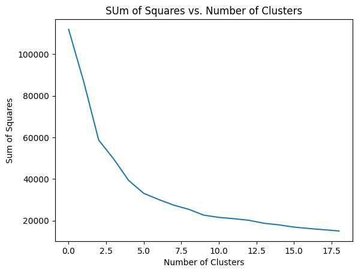

```python
# Find the best number K using inertia
inertia_lst = []
model_lst = []

for i in range(1,20):
  cluster_model = KMeans(n_clusters=i, random_state=42).fit(df_scaled)
  inertia_lst.append(cluster_model.inertia_)
  model_lst.append(cluster_model)

# plot results and use elbow method to find best number K
plt.plot(inertia_lst)
plt.title('SUm of Squares vs. Number of Clusters')
plt.xlabel('Number of Clusters')
plt.ylabel('Sum of Squares')
plt.show()
```

Analysis: Best K is between 2.5 and 5.0, so k=3 and K=4 will be used to find the best performing model.

```python
X_for_clustering = df_scaled.copy()

# Fit and Predict the clustering model with k = 3
kmeans1 = KMeans(n_clusters=3, random_state=42, n_init='auto').fit(X_for_clustering)
cluster1 = kmeans1.predict(X_for_clustering)

# Fit and Predict the clustering model with k = 4
kmeans2 = KMeans(n_clusters=4, random_state=42, n_init='auto').fit(X_for_clustering)
cluster2 = kmeans2.predict(X_for_clustering)
df_clean['cluster'] = cluster2

# Siloette Score and Davies Bouldin Score of each Model
print("Silhouette Score for k=3:", silhouette_score(X_for_clustering, cluster1))
print("Davies Bouldin Score for k=3:", davies_bouldin_score(X_for_clustering, cluster1))
print("Silhouette Score for k=4:", silhouette_score(X_for_clustering, cluster2))
print("Davies Bouldin Score for k=4:", davies_bouldin_score(X_for_clustering, cluster2))
```

```
Silhouette Score for k=3: 0.6406295559842984
Davies Bouldin Score for k=3: 0.7526467404934349
Silhouette Score for k=4: 0.6424410189522243
Davies Bouldin Score for k=4: 0.6440545011707637
```

Analysis: K = 4 performs better than K = 3, so the model for K = 4 will be used. cluster 2's Siloette Score indicates that clusters are well matched together and are cohesive. Cluster 2's Davies Bouldin Score indicates are somewhat clearly separated.

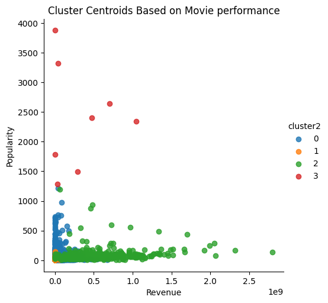

```python
# find cluster centroids
df_clean['cluster2'] = cluster2
centroids = kmeans2.cluster_centers_

sns.lmplot(x='revenue', y='popularity', data=df_clean, hue='cluster2', fit_reg=False, palette='tab10')
plt.title('Cluster Centroids Based on Movie performance')
plt.xlabel('Revenue')
plt.ylabel('Popularity')
plt.show()
```

```python
# -----------------------------------------------------
# Ensure 'genres_list' is correctly formed in df_clean
# -----------------------------------------------------
# Safely convert 'genres' column to a list of stripped genre strings
df_clean['genres'] = df_clean['genres'].astype(str) # ensure it's string type for split
df_clean['genres_list'] = df_clean['genres'].apply(lambda x: [g.strip() for g in x.split(',')] if pd.notna(x) and x != 'Unknown' else [])

# -----------------------------------------------------
# 1. Analyze numeric features per cluster
# -----------------------------------------------------
print("\n--- Numeric Feature Characteristics per Cluster ---\n")
numeric_cluster_summary = df_clean.groupby('cluster2')[['release_year', 'rating', 'popularity', 'vote_count', 'vote_average', 'budget', 'revenue']].mean()
print(numeric_cluster_summary)

# -----------------------------------------------------
# 2. Analyze categorical features per cluster
# -----------------------------------------------------
print("\n--- Categorical Feature Characteristics per Cluster ---\n")
for cluster_id in sorted(df_clean['cluster2'].unique()):
    print(f"\nCluster {cluster_id}:")

    # Type distribution
    type_dist = df_clean[df_clean['cluster2'] == cluster_id]['type'].value_counts(normalize=True).head(3)
    print(f"  Top Types:\n{type_dist}")

    # Language distribution
    lang_dist = df_clean[df_clean['cluster2'] == cluster_id]['language'].value_counts(normalize=True).head(3)
    print(f"  Top Languages:\n{lang_dist}")

    # Country distribution
    country_dist = df_clean[df_clean['cluster2'] == cluster_id]['country'].value_counts(normalize=True).head(3)
    print(f"  Top Countries:\n{country_dist}")

    # -----------------------------------------------------
    # 3. Analyze top genres per cluster
    # -----------------------------------------------------
    # Explode genres for this cluster's data
    cluster_genres = df_clean[df_clean['cluster2'] == cluster_id].explode('genres_list')
    cluster_genres = cluster_genres[cluster_genres['genres_list'] != 'Unknown'] # Exclude 'Unknown' genre

    if not cluster_genres.empty:
        top_genres_in_cluster = cluster_genres['genres_list'].value_counts(normalize=True).head(5)
        print(f"  Top 5 Genres:\n{top_genres_in_cluster}")
    else:
        print("  No specific genres found for this cluster (or all are 'Unknown').")
```

```
--- Numeric Feature Characteristics per Cluster ---

          release_year    rating   popularity   vote_count  vote_average  \
cluster2
0          2017.103833  6.320524    17.624680   476.396373      6.320524
1          2023.748754  0.227993    11.587549     1.669990      0.227993
2          2016.309278  6.894064    81.970823  9439.851546      6.894064
3          2024.500000  7.089125  2393.641750  1105.250000      7.089125

                budget       revenue
cluster2
0         4.984744e+06  1.009993e+07
1         1.639970e+06  1.200565e+05
2         1.352929e+08  4.994185e+08
3         8.850000e+07  3.226774e+08

--- Categorical Feature Characteristics per Cluster ---


Cluster 0:
  Top Types:
type
Movie    1.0
Name: proportion, dtype: float64
  Top Languages:
language
en    0.591630
fr    0.070463
ja    0.058605
Name: proportion, dtype: float64
  Top Countries:
country
United States of America    0.335769
Japan                       0.055019
South Korea                 0.045436
Name: proportion, dtype: float64
  Top 5 Genres:
genres_list
Drama       0.187493
Comedy      0.123235
```

[output cut: 66 more lines]

```
Name: proportion, dtype: float64
  Top Countries:
country
United States of America            0.625
United States of America, Japan     0.125
Canada, United States of America    0.125
Name: proportion, dtype: float64
  Top 5 Genres:
genres_list
Action             0.148148
Science Fiction    0.148148
Thriller           0.148148
Adventure          0.111111
Family             0.111111
Name: proportion, dtype: float64
```

Model #3 Evaluation:

For the clustering model, we tested different numbers of clusters and compared how well each option grouped the movies. We used the silhouette score and the Davies Bouldin score to judge how good the clusters were. Higher silhouette and lower Davies Bouldin scores mean the groups are clearer and more separated. Based on these metrics, k = 4 performed slightly better than k = 3, so we chose 4 clusters as the final model.

The clusters we got make sense from a business point of view. Each group showed different patterns in budget, revenue, ratings, popularity, and genres. For example, one cluster captured big budget, high revenue action and adventure movies, while another cluster represented low budget films with low engagement. This helps the business understand which types of content perform best and what characteristics they share.

The clustering model helps reveal useful patterns in the data. These insights can guide decisions on what kinds of movies or shows to invest in, which genres drive revenue, and where marketing efforts should focus.

# 9.Model Evaluation

**Comparison of models using a summary table or chart**

```python
import pandas as pd

# Model 1: Logistic Regression for Netflix Hit Prediction
model1_metrics = {
    'Model': 'Logistic Regression (Hit Prediction)',
    'Metric': 'Accuracy',
    'Value': 0.631875
}

# Model 2: Random Forest Regressor for Revenue Prediction
model2_metrics = {
    'Model': 'Random Forest Regressor (Revenue Prediction)',
    'Metric': 'R^2 Score',
    'Value': 0.761
}

# Model 3: KMeans Clustering
model3_metrics = {
    'Model': 'KMeans Clustering (k=4)',
    'Metric': 'Silhouette Score',
    'Value': 0.642441
}

# Create a DataFrame for comparison
comparison_df = pd.DataFrame([
    model1_metrics,
    model2_metrics,
    model3_metrics
])

# Display the comparison table
print("\n--- Model Comparison ---\n")
print(comparison_df.to_string(index=False))

# For KMeans, also add Davies Bouldin Score for completeness, though it's a different type of metric
model3_db_metrics = {
    'Model': 'KMeans Clustering (k=4)',
    'Metric': 'Davies Bouldin Score',
    'Value': 0.644055
}
comparison_df_extended = pd.DataFrame([
    model1_metrics,
    model2_metrics,
    model3_metrics,
    model3_db_metrics
])
print("\n--- Extended Model Comparison ---\n")
print(comparison_df_extended.to_string(index=False))
```

```
--- Model Comparison ---

                                       Model           Metric    Value
        Logistic Regression (Hit Prediction)         Accuracy 0.631875
Random Forest Regressor (Revenue Prediction)        R^2 Score 0.761000
                     KMeans Clustering (k=4) Silhouette Score 0.642441

--- Extended Model Comparison ---

                                       Model               Metric    Value
        Logistic Regression (Hit Prediction)             Accuracy 0.631875
Random Forest Regressor (Revenue Prediction)            R^2 Score 0.761000
                     KMeans Clustering (k=4)     Silhouette Score 0.642441
                     KMeans Clustering (k=4) Davies Bouldin Score 0.644055
```

**Interpretation of results in business terms (not just technical metrics)**

Flag promising projects early in development or acquisition: It helps prioritize content that statistically has a higher chance of being well-received. Allocate marketing resources more effectively: Direct more marketing efforts towards titles that the model predicts as hits. Identify 'risky' content: Content with a low predicted 'hit' probability might warrant re-evaluation or alternative strategies, potentially minimizing losses on less engaging titles. Random Forest Regressor (Revenue Prediction): An R^2 score of 0.761 is quite strong, meaning this model can explain about 76% of the variability in a title's revenue. From a business perspective, this is invaluable because it tells us what factors are most strongly linked to financial success. The previous feature importance analysis (where budget and vote count were key drivers) suggests that:

Strategic Investment: Netflix should continue to invest significantly in high-budget productions, as these correlate strongly with higher revenue. Engagement Focus: Content that generates high viewer engagement (leading to higher vote_count) is critical for revenue. This emphasizes the importance of creating compelling content that viewers actively interact with, not just passively watch. Optimizing Content Portfolio: This model can help Netflix prioritize projects that align with these revenue-driving characteristics, enabling better allocation of its multi-billion dollar content budget. KMeans Clustering (Content Segmentation): The clustering results (with good Silhouette and Davies Bouldin scores) indicate that Netflix's content can be meaningfully segmented into distinct groups. This is useful for:

Targeted Content Strategy: Netflix can understand the unique characteristics of each content cluster (e.g., one cluster might be high-budget action films, another might be niche foreign documentaries). This allows for tailored acquisition, production, and marketing strategies for different types of content and audience segments. Identifying Market Gaps and Opportunities: By analyzing the traits of successful clusters, Netflix can identify what types of content are thriving and where there might be opportunities to expand or innovate. Conversely, underperforming clusters might signal areas to reduce investment or rethink the approach. Personalization and Recommendations: Better understanding of content clusters can enhance the recommendation engine, ensuring that users are served content that is more likely to match their preferences based on the characteristics of successful content groups.

# 10.Conclusions & Recommendations

**Best model choice and why**

The Random Forest Regressor is the best model overall because it provides strong predictive accuracy, direct financial relevance, and strategic interpretability. It enables Netflix to quantify potential returns on content investments — guiding smarter, data-driven decision-making for both production and marketing strategies.

**Suggestions for next steps or further analysis**

1. Incorporate Additional Data Sources Enhance the models by including richer features such as cast popularity, social media buzz, marketing spend, and viewer retention rates. These variables can capture external factors that heavily influence content success but aren’t reflected in the current dataset, leading to more accurate and actionable predictions.
2. Conduct Audience Segmentation and Trend Forecasting Use clustering results to profile distinct viewer segments and track how their preferences evolve over time. Incorporating time-series forecasting could help Netflix anticipate future genre trends, seasonal demand shifts, and emerging global content opportunities — guiding smarter content investment and release timing decisions.